# GeoPick

This Notebook illustrates how GeoPick calculates the smallest enclosing circle of a geometry, i.e. its uncertainty. The example given below is for a polygon with a corrected center ([Chapman & Wilczorek, 2020](https://docs.gbif.org/georeferencing-best-practices/1.0/en/#corrected-center), [Zermoglio et al., 2020](https://docs.gbif.org/georeferencing-quick-reference-guide/1.0/en/#s-corrected-center)). For line, polyline and multipolygon geometries the calculation is analogous.

```r
library(jsonlite)
library(sf)
library(geojsonsf)
library(lwgeom)
library(terra)
library(mapview)
library(ggplot2)
library(gridExtra)
library(leaflet)
library(dplyr)
source("functions.R")
source("capdecreus.R")
f <- "../data/CNTR_RG_01M_2020_4326.geojson"
world.4326 <- geojson_sf(f)["ISO3_CODE"]
```

## 1 - Specimen’s locality interpretation

The polygon below represents the geometry resulting from retrospective georeferencing, the process by which the locality where a specimen was collected is interpreted over a map from the description in the specimen’s associated metadata (tag, field notebook, etc.).

```r
site.sf <- st_as_sf(st_as_sfc(site.wkt, crs = 4326))
site.sf <- st_as_sf(st_combine(site.sf))
leaflet() %>%
  addTiles() %>%
  addPolygons(data=site.sf, col = "red")
```

[interactive chart not shown]

## 2 - Azimuth Equal-Area projection centered on site’s centroid

We need to reproject the geometry from WGS84, which results from digitizing with GeoPick, into a projection which does not distort distances in order to correctly apply the minimum bounding circle, *aka* smallest enclosing circle, algorithm. GeoPick uses the [Azimuthal Equal Area (AEQD) projection](https://proj.org/en/9.3/operations/projections/aeqd.html) for this purpose. GeoPick calculates the centroid of the digitized site in WGS84 as an approximation to the center on which to focus the projection.

```r
centroid <- st_centroid(site.sf)
xc <- st_coordinates(centroid)[1]
yc <- st_coordinates(centroid)[2]
crs <- paste0("+proj=aeqd +lat_0=", yc, " +lon_0=", xc,
              " +x_0=0 +y_0=0 +R=6371000 +units=m +no_defs +type=crs")
site.tr <- site.sf %>% st_transform(crs)
```

For the given example, the parameterized projection is +proj=aeqd +lat_0=42.25042729657 +lon_0=3.23921344496318 +x_0=0 +y_0=0 +R=6371000 +units=m +no_defs +type=crs. Below we can see the Earth projected with our site at its center.

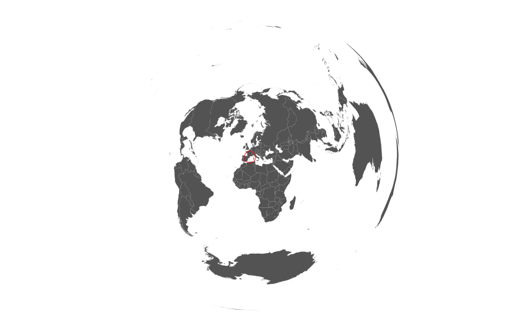

```r
world.tr <- world.4326 %>% st_transform(crs)
bbox <- st_bbox(site.tr)
buf <- 25
bbox.buf <- c(bbox$xmin - abs(bbox$xmin) * buf,
              bbox$ymin - abs(bbox$ymin) * buf,
              bbox$xmax + abs(bbox$xmax) * buf,
              bbox$ymax + abs(bbox$ymax) * buf)
site.world <- st_crop(world.tr, bbox.buf)
p.world <- ggplot() +
  geom_sf(data=world.tr, fill="grey40", linewidth=0) +
  geom_point(aes(x=xc, y=yc), col="red", shape=21, size=7) +
  theme_void()
p.world
```

## 3 - Simplify site

If the geometry is too large, GeoPick simplifies it for performance reasons. Currently, the maximum number of vertices is set to 10 000 and the tolerance used when simplifying is needed is 500m.

```r
max_points_polygon <- 10000
if(npts(site.tr) > as.integer(max_points_polygon)){
  site.tr <- st_simplify(site.tr, preserveTopology = TRUE, dTolerance = tolerance)
  cat("In our example, the geometry HAS BEEN SIMPLIFIED since it had", npts(site.tr), "vertices\n")
} else {
    cat("In our example, the geometry HAS NOT BEEN SIMPLIFIED since it had", npts(site.tr), "vertices\n")
}
```

In our example, the geometry HAS NOT BEEN SIMPLIFIED since it had 252 vertices

## 4- Calculate SEC and centroid

With the site projected in AEQD, GeoPick calculates the Smallest Enclosing Circle and its corresponding centroid and radius of uncertainty.

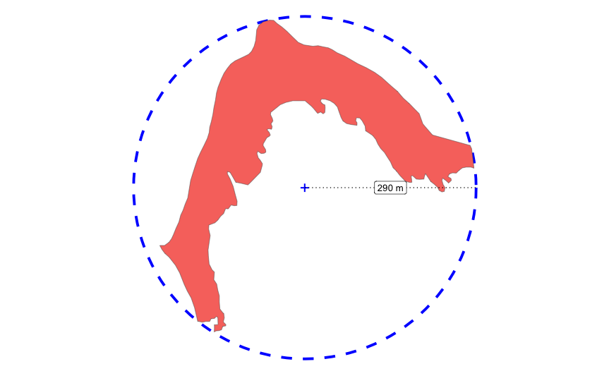

```r
mbc.tr <- st_minimum_bounding_circle(site.tr, nQuadSegs = 30)
mbc.tr.centroid <- st_centroid(mbc.tr)
xc <- st_coordinates(mbc.tr.centroid)[1]
yc <- st_coordinates(mbc.tr.centroid)[2]
radius.line <- st_as_sfc(paste0("LINESTRING (", xc, " ", yc, ", ",
                                st_bbox(mbc.tr)["xmax"], " ", yc, ")")) %>%
  st_set_crs(crs)

p <- ggplot() +
  geom_sf(data=mbc.tr, fill=NA, col = "blue", linewidth = 1.5, linetype = "dashed") +
  geom_sf(data=site.tr, aes(fill="red")) +
  geom_sf(data=mbc.tr.centroid, shape = '+', col = "blue", size = 7, linewidth = 2) +
  geom_sf(data=radius.line, linewidth = 0.5, linetype = "dotted") +
  geom_label(aes(x = xc + (st_bbox(mbc.tr)["xmax"] - xc)/2, y = yc),
             label = paste(round(st_length(radius.line)), "m")) +
  theme_void() +
  theme(legend.position = "None")
p
```

## 5 - Correct center if necessary, if not go to 6

When the centroid falls outside the geometry, GeoPick calculates the corrected center instead ([Chapman & Wilczorek, 2020](https://docs.gbif.org/georeferencing-best-practices/1.0/en/#corrected-center), [Zermoglio et al., 2020](https://docs.gbif.org/georeferencing-quick-reference-guide/1.0/en/#s-corrected-center)). It follows these steps.

```r
need.cc <- ifelse(is.na(as.integer(st_intersects(site.tr, mbc.tr.centroid))), T, F)
n.sample <- 50
n.nearest <- 10
if(need.cc){
  site.pts <- st_cast(site.tr, "POINT") %>% mutate(idx = row.names(.))
  if(nrow(site.pts) > n.sample){
    point.idxs <- sample(1:nrow(site.pts), n.sample)
    candidate.pts <- site.pts %>% slice(point.idxs)
  } else {
    candidate.pts <- site.pts
  }
  # We add the closest point from non-corrected center to site.tr, whether or not it is a vertex, as
  # a new candidate, since it may well be a good candidate.
  pt <- getNearestPointOnGeometry(site.tr, mbc.tr.centroid, crs) %>%
    mutate(idx = max(as.numeric(candidate.pts$idx)) + 1)

  candidate.pts <- rbind(candidate.pts, pt)
  sec <- approximateSEC(site.pts, candidate.pts, NA, 10^8)

  # Once we have a first approximation through randomization, we explore the neighbours of the selected
  # point in order to to see if one of them still improves the sec
  nearest.pts <- getNearestPoints(site.pts, sec$center, n.nearest)
  sec.final <- approximateSEC(site.pts, nearest.pts, sec$center, sec$radius)
  radius.final <- sec$radius
  mbc.tr.corrected.centroid <- sec.final$center %>% dplyr::select(-idx)
  mbc.tr.corrected <- st_as_sf(terra::buffer(vect(mbc.tr.corrected.centroid), radius.final))
}
```

### 1) Candidates to become the new corrected center

GeoPick creates a list of possible candidates to the new corrected center by taking a sample c) from a) plus b) (see below).

#### a) Nearest point (green dot) to the centroid (blue cross).

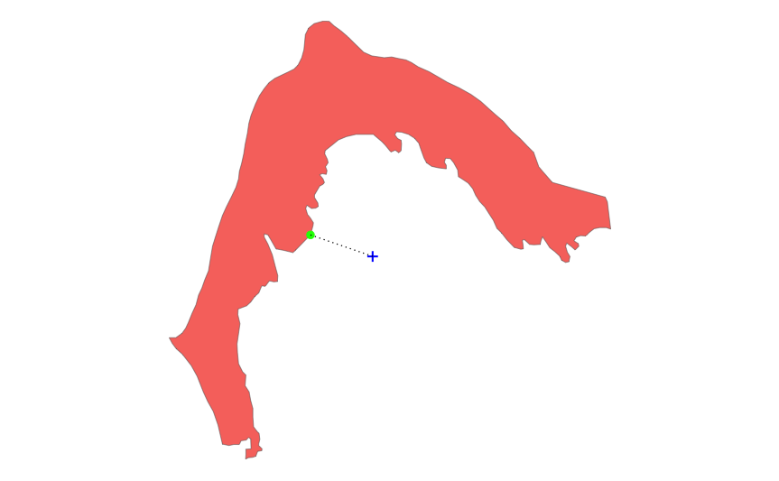

```r
if(need.cc){
  p <- ggplot() +
  geom_sf(data=site.tr, aes(fill="red")) +
  geom_sf(data=pt, colour = "green", shape = 21, fill = "green", size = 3) +
  geom_sf(data=mbc.tr.centroid, shape = '+', colour = "blue", size = 7) +
  geom_segment(aes(x = st_coordinates(pt)[1], y = st_coordinates(pt)[2],
                   xend = st_coordinates(mbc.tr.centroid)[1], yend = st_coordinates(mbc.tr.centroid)[2]),
               linetype = "dotted") +
  theme_void() + theme(legend.position = "None")
p
}
```

#### b) Geometry vertices (black dots).

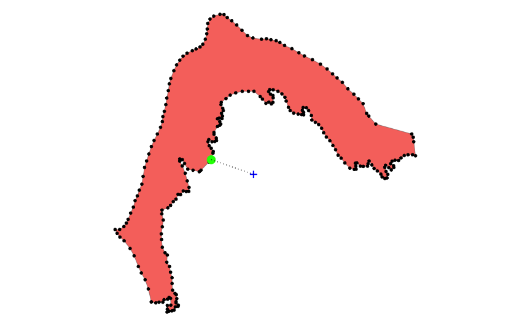

```r
if(need.cc){
p <- ggplot() +
  geom_sf(data=site.tr, aes(fill="red")) +
  geom_sf(data=mbc.tr.centroid, shape = '+', colour = "blue", size = 7) +
  geom_sf(data=site.pts) +
  geom_sf(data=pt, colour = "green", shape = 21, fill = "green", size = 5) +
    geom_segment(aes(x = st_coordinates(pt)[1], y = st_coordinates(pt)[2],
                   xend = st_coordinates(mbc.tr.centroid)[1], yend = st_coordinates(mbc.tr.centroid)[2]),
               linetype = "dotted") +
  theme_void() + theme(legend.position = "None")
p
}
```

#### c) Final sample (yellow dots) of candidate points.

For performance reasons, GeoPick takes a sample of 50 points from all candidate points.

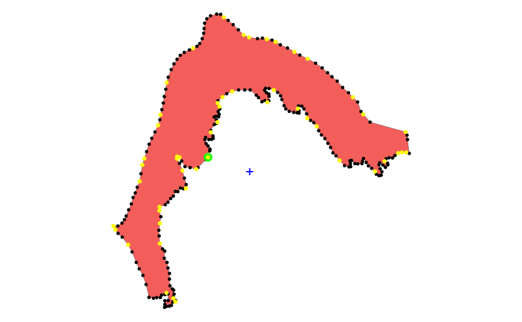

```r
if(need.cc){
p <- ggplot() +
  geom_sf(data=site.tr, aes(fill="red")) +
  geom_sf(data=mbc.tr.centroid, shape = '+', colour = "blue", size = 7) +
  geom_sf(data=site.pts) +
    geom_sf(data=pt, colour = "green", shape = 21, fill = "green", size = 5) +
  geom_sf(data=candidate.pts, shape = 19, colour = "yellow", size = 2) +
  theme_void() + theme(legend.position = "none")
p
}
```

### 2) - Calculation of corrected

#### a) - First approximation

GeoPick now selects among the candidate points (yellow dots) which is the best candidate for the corrected center, i.e. the one minimizing uncertainty (red cross).

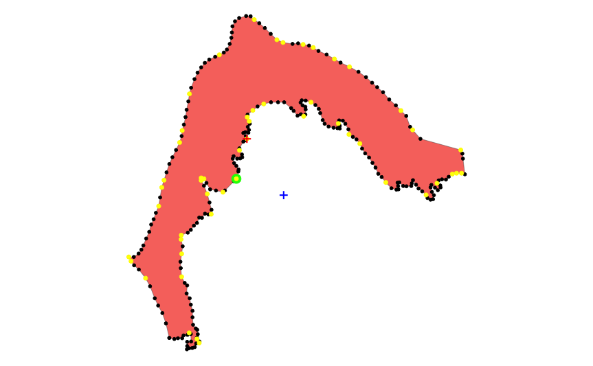

```r
if(need.cc){
p <- ggplot() +
  geom_sf(data=site.tr, aes(fill="red")) +
  geom_sf(data=mbc.tr.centroid, shape = '+', colour = "blue", size = 7) +
  geom_sf(data=site.pts) +
    geom_sf(data=pt, colour = "green", shape = 21, fill = "green", size = 5) +
  geom_sf(data=candidate.pts, shape = 19, colour = "yellow", size = 2) +
  geom_sf(data=sec$center, shape = '+', colour = "red", size = 7) +
  theme_void() + theme(legend.position = "none")
p
}
```

#### b) Second approximation

To further explore possible better alternative corrected centers, GeoPick explores the 10 neighbours of the firs approximated centroid, in order to find still a better candidate as center of the smallest enclosing circle. In this first approximation, the candidate for the corrected center is shown as a red cross.

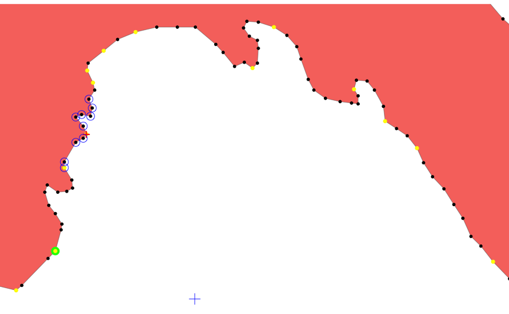

```r
if(need.cc){
p <- ggplot() +
  geom_sf(data=site.tr, aes(fill="red")) +
  geom_sf(data=mbc.tr.centroid, shape = 3, colour = "blue", size = 5) +
  geom_sf(data=site.pts) +
    geom_sf(data=pt, colour = "green", shape = 21, fill = "green", size = 5) +
  geom_sf(data=candidate.pts, shape = 19, colour = "yellow", size = 2) +
  geom_sf(data=sec$center, shape = '+', colour = "red", size = 7) +
  geom_sf(data=nearest.pts, shape = 21, colour = "blue", size = 5) +
  xlim(c(-70, 180)) +
  ylim(c(-80, 70)) +
  theme_void() + theme(legend.position = "none")
p

}
```

#### c) Final selection of best corrected center.

Finally, GeoPick uses the final best candidate vertex (blue dot) from the process.

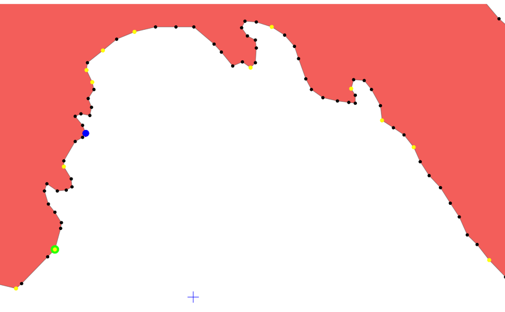

```r
if(need.cc){
  p <- ggplot() +
  geom_sf(data=site.tr, aes(fill="red")) +
  geom_sf(data=mbc.tr.centroid, shape = 3, colour = "blue", size = 5) +
  geom_sf(data=site.pts) +
    geom_sf(data=pt, colour = "green", shape = 21, fill = "green", size = 5) +
  geom_sf(data=candidate.pts, shape = 19, colour = "yellow", size = 2) +
  geom_sf(data=sec$center, shape = '+', colour = "red", size = 7) +

  geom_sf(data=sec.final$center, shape = 20, colour = "blue", size = 6) +
    xlim(c(-70, 180)) +
  ylim(c(-80, 70)) +
  theme_void() + theme(legend.position = "none")
p

p
}
```

### 3) - Final corrected center and associated uncertainty (in AEQD projection).

The distance from the corrected center to the furthest vertex in the geometry defines the smallest enclosing circle and, thus, the uncertainty.

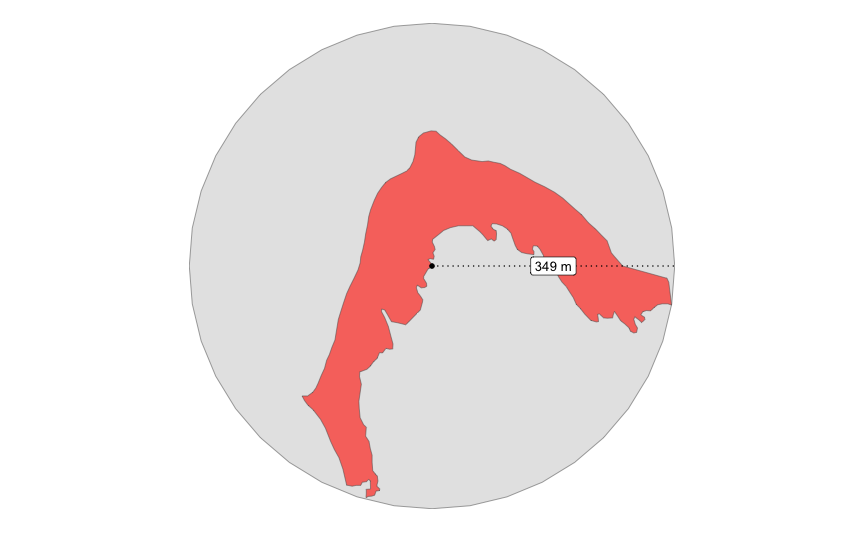

```r
if(need.cc){
xc.tr <- st_coordinates(sec.final$center)[1]
yc.tr <- st_coordinates(sec.final$center)[2]
radius.line <- st_as_sfc(paste0("LINESTRING (", xc.tr, " ", yc.tr, ", ",
                                st_bbox(mbc.tr.corrected)["xmax"], " ", yc.tr, ")")) %>%
  st_set_crs(crs)

ggplot() +
  geom_sf(data=mbc.tr.corrected) +
  geom_sf(data=site.tr, aes(fill="red")) +
  geom_sf(data=sec.final$center) +
  geom_sf(data=radius.line, linewidth = 0.5, linetype = "dotted") +
  geom_label(aes(x = xc.tr + (st_bbox(mbc.tr.corrected)["xmax"] - xc.tr)/2, y = yc.tr),
             label = paste(round(st_length(radius.line)), "m")) +
  theme_void() +
  theme(legend.position = "none")
}
```

## 6 - Reprojection back to WGS84

```r
# Transform mbc back to wgs84 in geojson
if(need.cc){
mbc.4326 <- st_transform(mbc.tr.corrected, 4326)
# Transform centroid back to wgs84 in geojson
centroid <- st_as_sf(mbc.tr.corrected.centroid) %>% st_transform(4326)
} else {
mbc.4326 <- st_transform(mbc.tr, 4326)
# Transform centroid back to wgs84 in geojson
centroid <- st_as_sf(mbc.tr.centroid) %>% st_transform(4326)
}

leaflet() %>%
  addTiles() %>%
  addPolygons(data=mbc.4326, opacity = 0.25) %>%
  addPolygons(data=site.sf, col = "red") %>%
  # addCircleMarkers(data=centroid, color = "red", radius = 1)
  addMarkers(data=centroid)
```

[interactive chart not shown]

**Site’s centroid**  
*Latitude, Longitude (dd):* 42.250492 3.238778  
*Uncertainty (m):* 349 m

## References

- Chapman AD & Wieczorek JR (2020) Georeferencing Best Practices. Copenhagen: GBIF Secretariat. https://doi.org/10.15468/doc-gg7h-s853
- Zermoglio PF, Chapman AD, Wieczorek JR, Luna MC & Bloom DA (2020) Georeferencing Quick Reference Guide. Copenhagen: GBIF Secretariat. https://doi.org/10.35035/e09p-h128